{% raw %}

{% endraw %} {% raw %}

{% endraw %}

Neural Network Pruning usually follows one of the next 3 schedules:

[figure not shown]

In fasterai, all those 3 schedules can be applied from the **same** callback. We'll cover each below

## One-Shot Pruning

The simplest way to perform pruning is called One-Shot Pruning. It consists of the following three steps:

1. You first need to train a network
2. You then need to remove some weights (depending on your criteria, needs,...)
3. You fine-tune the remaining weights to recover from the loss of parameters.

With fasterai, this is really easy to do. Let's illustrate it by an example:

{% raw %}

```python
path = untar_data(URLs.PETS)

files = get_image_files(path/"images")

def label_func(f): return f[0].isupper()

device = 'cuda:0' if torch.cuda.is_available() else 'cpu'

dls = ImageDataLoaders.from_name_func(path, files, label_func, item_tfms=Resize(64), device=device)
```

{% endraw %}

We will first train a network without any pruning, which will serve as a baseline.

{% raw %}

```python
learn = cnn_learner(dls, resnet18, metrics=accuracy)
learn.unfreeze()

learn.fit_one_cycle(3)
```

| epoch | train_loss | valid_loss | accuracy | time |
| --- | --- | --- | --- | --- |
| 0 | 0.640964 | 0.633472 | 0.846414 | 00:12 |
| 1 | 0.331340 | 0.272124 | 0.895129 | 00:12 |
| 2 | 0.181170 | 0.211167 | 0.912720 | 00:12 |

{% endraw %}

There are two main ways that you can perform One-Shot Pruning with fasterai.

1. You already possess a trained network and want to prune it
2. You don't possess such a network and have to train it from scratch

### 1. You possess a trained network

In this case, the step 1) of the One-Shot Pruning process is already done. But you still need to prune the network and then fine-tune it.

Let's say we want to remove $80 \%$ of the weights of our network. This can be done as:

{% raw %}

```python
sp = Sparsifier(learn.model, 'weight', 'global', l1_norm)
sp.prune(80)
```

{% endraw %} {% raw %}

```python
_, acc = learn.validate(); acc
```

```
0.8179972767829895
```

{% endraw %}

Obviously, as we removed a good part of trained weights, the perfomance of the network is degraded. This can be solved by retraining our pruned network, making sure that the pruned weights keep their 0 value.

We don't want to update the sparsity level anymore so we have to create a schedule that returns a constant value. Such a schedule exists in fasterai and is called `one_shot` and is defined as:

{% raw %}

```python
def one_shot(start, end, pos): return end
```

{% endraw %}

We can pass the same arguments to our callback than those used by the Sparsifier.

{% raw %}

```python
sp_cb=SparsifyCallback(sparsity=80, granularity='weight', method='global', criteria=l1_norm, sched_func=one_shot)

learn.fit_one_cycle(3, cbs=sp_cb)
```

```
Pruning of weight until a sparsity of 80%
Saving Weights at epoch 0
```

| epoch | train_loss | valid_loss | accuracy | time |
| --- | --- | --- | --- | --- |
| 0 | 0.199193 | 0.281678 | 0.903248 | 01:36 |
| 1 | 0.167149 | 0.207365 | 0.916103 | 01:35 |
| 2 | 0.083820 | 0.196808 | 0.928281 | 01:34 |

```
Sparsity at the end of epoch 0: 80.00%
Sparsity at the end of epoch 1: 80.00%
Sparsity at the end of epoch 2: 80.00%
Final Sparsity: 80.00
```

{% endraw %}

We can also check where the pruned weights are in the network

{% raw %}

```python
for k,m in enumerate(learn.model.modules()):
    if isinstance(m, nn.Conv2d):
        print(f"Sparsity in {m.__class__.__name__} {k}: {100. * float(torch.sum(m.weight == 0))/ float(m.weight.nelement()):.2f}%")
```

```
Sparsity in Conv2d 2: 38.85%
Sparsity in Conv2d 8: 55.18%
Sparsity in Conv2d 11: 50.22%
Sparsity in Conv2d 14: 48.10%
Sparsity in Conv2d 17: 49.92%
Sparsity in Conv2d 21: 53.43%
Sparsity in Conv2d 24: 60.85%
Sparsity in Conv2d 27: 42.36%
Sparsity in Conv2d 30: 60.02%
Sparsity in Conv2d 33: 62.29%
Sparsity in Conv2d 37: 65.71%
Sparsity in Conv2d 40: 70.78%
Sparsity in Conv2d 43: 61.05%
Sparsity in Conv2d 46: 74.60%
Sparsity in Conv2d 49: 77.16%
Sparsity in Conv2d 53: 77.67%
Sparsity in Conv2d 56: 82.73%
Sparsity in Conv2d 59: 59.82%
Sparsity in Conv2d 62: 80.74%
Sparsity in Conv2d 65: 91.73%
```

{% endraw %}

{% include note.html content='Using Sparsifier to prune the network is not necessary as it will also be called in the Callback. This was used here to better illustrate all the steps.' %}

### 2. You don't possess a trained network

{% raw %}

```python
learn = cnn_learner(dls, resnet18, metrics=accuracy)
learn.unfreeze()
```

{% endraw %}

In this case, your network needs to be trained before pruning.

You only need to create the Callback with the `one_shot` schedule and set the `start_epoch` argument, i.e. how many epochs you want to train your network before pruning it.

{% raw %}

```python
sp_cb=SparsifyCallback(sparsity=80, granularity='weight', method='global', criteria=l1_norm, sched_func=one_shot, start_epoch=3)
```

{% endraw %}

Let's start pruningn after 3 epochs and train our model for 6 epochs to have the same total amount of training as before

{% raw %}

```python
learn.fit_one_cycle(6, cbs=sp_cb)
```

```
Pruning of weight until a sparsity of 80%
Saving Weights at epoch 0
```

| epoch | train_loss | valid_loss | accuracy | time |
| --- | --- | --- | --- | --- |
| 0 | 0.702169 | 0.456472 | 0.870095 | 00:11 |
| 1 | 0.410011 | 0.288117 | 0.881597 | 00:11 |
| 2 | 0.250258 | 0.252269 | 0.889716 | 00:12 |
| 3 | 0.145373 | 0.176909 | 0.933694 | 01:37 |
| 4 | 0.083379 | 0.201312 | 0.929635 | 01:34 |
| 5 | 0.054683 | 0.208249 | 0.933694 | 01:36 |

```
Sparsity at the end of epoch 0: 0.00%
Sparsity at the end of epoch 1: 0.00%
Sparsity at the end of epoch 2: 0.00%
Sparsity at the end of epoch 3: 80.00%
Sparsity at the end of epoch 4: 80.00%
Sparsity at the end of epoch 5: 80.00%
Final Sparsity: 80.00
```

{% endraw %}

Actually, doing the training and pruning in a single cycle works even better !

## Iterative Pruning

Researchers have come up with a better way to do pruning than pruning all the weigths in once (as in One-Shot Pruning). The idea is to perform several iterations of pruning and fine-tuning and is thus called Iterative Pruning.

1. You first need to train a network
2. You then need to remove a part of the weights weights (depending on your criteria, needs,...)
3. You fine-tune the remaining weights to recover from the loss of parameters.
4. Back to step 2.

{% raw %}

```python
learn = cnn_learner(dls, resnet18, metrics=accuracy)
learn.unfreeze()
```

{% endraw %}

In this case, your network needs to be trained before pruning.

You only need to create the Callback with the `iterative` schedule and set the `start_epoch` argument, i.e. how many epochs you want to train your network before pruning it.

{% raw %}

```python
def iterative(start, end, pos, n_steps=3):
    "Perform iterative pruning, and pruning in `n_steps` steps"
    return start + ((end-start)/n_steps)*(np.ceil((pos)*n_steps))
```

{% endraw %}

The `iterative` schedules has a `n_steps`parameter, i.e. how many iterations of pruning/fine-tuning you want to perform. To modify its value, we can use the `partial` function like this:

```
iterative = partial(iterative, n_steps=5)
```

{% raw %}

```python
sp_cb=SparsifyCallback(sparsity=80, granularity='weight', method='global', criteria=l1_norm, sched_func=iterative, start_epoch=3)
```

{% endraw %}

Let's start pruningn after 3 epochs and train our model for 6 epochs to have the same total amount of training as before

{% raw %}

```python
learn.fit_one_cycle(6, cbs=sp_cb)
```

```
Pruning of weight until a sparsity of 80%
Saving Weights at epoch 0
```

| epoch | train_loss | valid_loss | accuracy | time |
| --- | --- | --- | --- | --- |
| 0 | 0.678416 | 0.811682 | 0.843031 | 00:12 |
| 1 | 0.448310 | 0.305697 | 0.878214 | 00:12 |
| 2 | 0.243350 | 0.223050 | 0.905954 | 00:11 |
| 3 | 0.140957 | 0.207141 | 0.929635 | 01:37 |
| 4 | 0.082162 | 0.199370 | 0.927605 | 01:34 |
| 5 | 0.068106 | 0.171238 | 0.930988 | 01:36 |

```
Sparsity at the end of epoch 0: 0.00%
Sparsity at the end of epoch 1: 0.00%
Sparsity at the end of epoch 2: 0.00%
Sparsity at the end of epoch 3: 26.67%
Sparsity at the end of epoch 4: 53.33%
Sparsity at the end of epoch 5: 80.00%
Final Sparsity: 80.00
```

{% endraw %}

## Gradual Pruning

{% raw %}

```python
learn = cnn_learner(dls, resnet18, metrics=accuracy)
learn.unfreeze()
```

{% endraw %} {% raw %}

```python
sp_cb=SparsifyCallback(sparsity=80, granularity='weight', method='global', criteria=l1_norm, sched_func=sched_agp)
```

{% endraw %}

{% raw %}

```python
learn.fit_one_cycle(6, cbs=sp_cb)
```

```
Pruning of weight until a sparsity of 80%
Saving Weights at epoch 0
```

| epoch | train_loss | valid_loss | accuracy | time |
| --- | --- | --- | --- | --- |
| 0 | 0.620968 | 0.493531 | 0.855886 | 01:34 |
| 1 | 0.395395 | 0.336614 | 0.877537 | 01:36 |
| 2 | 0.255663 | 0.199090 | 0.921516 | 01:33 |
| 3 | 0.157263 | 0.181541 | 0.924222 | 01:35 |
| 4 | 0.099781 | 0.169471 | 0.933694 | 01:33 |
| 5 | 0.062961 | 0.175360 | 0.937077 | 01:36 |

```
Sparsity at the end of epoch 0: 33.70%
Sparsity at the end of epoch 1: 56.30%
Sparsity at the end of epoch 2: 70.00%
Sparsity at the end of epoch 3: 77.04%
Sparsity at the end of epoch 4: 79.63%
Sparsity at the end of epoch 5: 80.00%
Final Sparsity: 80.00
```

{% endraw %}

Even though they are often considered as different pruning methods, those 3 schedules can be captured by the same Callback. Here is how the sparsity in the network evolves for those methods;

Let's take an example here. Let's say that we want to train our network for 3 epochs without pruning and then 7 epochs with pruning.

{% raw %}

```python
train = np.zeros(300)
prune = np.linspace(0,1, 700)
```

{% endraw %}

Then this is what our different pruning schedules will look like:

{% raw %}

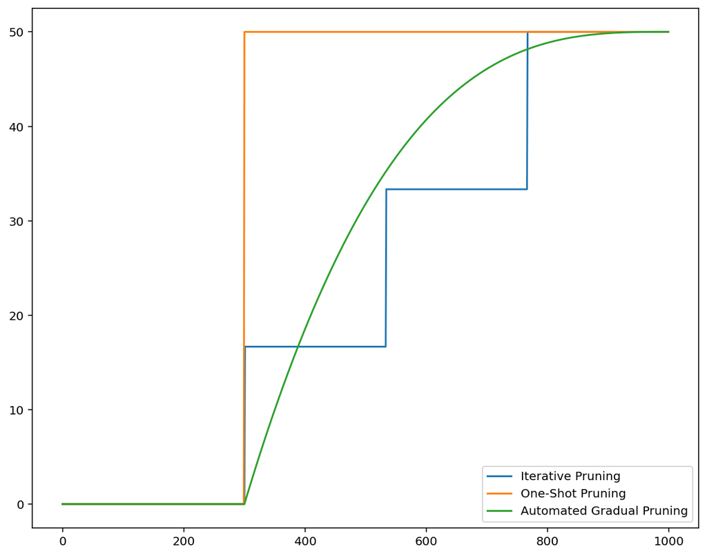

```python
plt.figure(figsize=(10,8))
plt.plot(np.concatenate([train, iterative(0,50, prune)]), label='Iterative Pruning')
plt.plot(np.concatenate([train, os]), label='One-Shot Pruning')
plt.plot(np.concatenate([train, sched_agp(0,50, prune)]), label='Automated Gradual Pruning')
plt.legend()
```

{% endraw %}

**You can also come up with your own pruning schedule !**